# Prediction of dementia from MRI data

Emma Rand

28/10/2020

short cut for insert is control-alt-i

```r
library(tidyverse)
library(GGally)
library(caret)
```

# Introduction

**Dementia** is a decline in mental ability which interferes with daily life. It describes a group of symptoms associated with a decline in memory and thinking skills. It is not a disease and there is not a single test to determine if a person has dementia. Instead, a combination of medical history, physical examination and mental acuity tests are used to diagnose dementia.

# Data

The data in Oasis_longitudinal.csv consists of a longitudinal collection of 150 subjects aged 60 to 96. Each subject was scanned on two or more visits, separated by at least one year for a total of 373 imaging sessions. For each subject, 3 or 4 individual T1-weighted MRI scans obtained in single scan sessions are included. The subjects are all right-handed and include both men and women. 72 of the subjects were characterized as nondemented throughout the study. 64 of the included subjects were characterized as demented at the time of their initial visits and remained so for subsequent scans, including 51 individuals with mild to moderate Alzheimer’s disease. Another 14 subjects were characterized as nondemented at the time of their initial visit and were subsequently characterized as demented at a later visit.

```r
# import data
subjects <- read_csv("data-raw/oasis_longitudinal.csv") %>%
  select(-Hand) %>%
  janitor::clean_names()
```

## Variables

There are 14 variables which are:

```r
glimpse(subjects)
```

```
## Rows: 373
## Columns: 14
## $ subject_id <chr> "OAS2_0001", "OAS2_0001", "OAS2_0002", "OAS2_0002", "OAS2_0~
## $ mri_id     <chr> "OAS2_0001_MR1", "OAS2_0001_MR2", "OAS2_0002_MR1", "OAS2_00~
## $ group      <chr> "Nondemented", "Nondemented", "Demented", "Demented", "Deme~
## $ visit      <dbl> 1, 2, 1, 2, 3, 1, 2, 1, 2, 3, 1, 3, 4, 1, 2, 1, 2, 1, 2, 1,~
## $ mr_delay   <dbl> 0, 457, 0, 560, 1895, 0, 538, 0, 1010, 1603, 0, 518, 1281, ~
## $ m_f        <chr> "M", "M", "M", "M", "M", "F", "F", "M", "M", "M", "M", "M",~
## $ age        <dbl> 87, 88, 75, 76, 80, 88, 90, 80, 83, 85, 71, 73, 75, 93, 95,~
## $ educ       <dbl> 14, 14, 12, 12, 12, 18, 18, 12, 12, 12, 16, 16, 16, 14, 14,~
## $ ses        <dbl> 2, 2, NA, NA, NA, 3, 3, 4, 4, 4, NA, NA, NA, 2, 2, 2, 2, 3,~
## $ mmse       <dbl> 27, 30, 23, 28, 22, 28, 27, 28, 29, 30, 28, 27, 27, 30, 29,~
## $ cdr        <dbl> 0.0, 0.0, 0.5, 0.5, 0.5, 0.0, 0.0, 0.0, 0.5, 0.0, 0.5, 1.0,~
## $ e_tiv      <dbl> 1987, 2004, 1678, 1738, 1698, 1215, 1200, 1689, 1701, 1699,~
## $ n_wbv      <dbl> 0.696, 0.681, 0.736, 0.713, 0.701, 0.710, 0.718, 0.712, 0.7~
## $ asf        <dbl> 0.883, 0.876, 1.046, 1.010, 1.034, 1.444, 1.462, 1.039, 1.0~
```

- group Converted / Demented / Nondemented
- mr_delay - I think this is time since the MRI?
- m_f - Gender
- educ - Years of education
- ses - Socioeconomic status as assessed by the Hollingshead Index of Social Position and classified into categories from 1 (highest status) to 5 (lowest status)
- mmse - Mini-Mental State Examination score (range is from 0 = worst to 30 = best). Score greater than or equal to 24 points (out of 30) indicates a normal cognition. Below this, scores can indicate severe (≤9 points), moderate (10–18 points) or mild (19–23 points) cognitive impairment.
- cdr - Clinical Dementia Rating (0 = no dementia, 0.5 = very mild AD, 1 = mild AD, 2 = moderate AD)
- e_tiv - Estimated total intracranial volume, mm3
- n_wbv - Normalized whole-brain volume, expressed as a percent of all voxels in the atlas-masked image that are labeled as gray or white matter by the automated tissue segmentation process
- asf - Atlas scaling factor (unitless). Computed scaling factor that transforms native-space brain and skull to the atlas target (i.e., the determinant of the transform matrix)

Either group or cdr could be considered response variables. Hand is not informative and was dropped leaving 12 potential explanatory variables. Or mmse

```r
# turn cdr into a factor
subjects$cdr <- factor(subjects$cdr)
```

## Overview

```r
summary(subjects)
```

```
##   subject_id           mri_id             group               visit
##  Length:373         Length:373         Length:373         Min.   :1.000
##  Class :character   Class :character   Class :character   1st Qu.:1.000
##  Mode  :character   Mode  :character   Mode  :character   Median :2.000
##                                                           Mean   :1.882
##                                                           3rd Qu.:2.000
##                                                           Max.   :5.000
##
##     mr_delay          m_f                 age             educ
##  Min.   :   0.0   Length:373         Min.   :60.00   Min.   : 6.0
##  1st Qu.:   0.0   Class :character   1st Qu.:71.00   1st Qu.:12.0
##  Median : 552.0   Mode  :character   Median :77.00   Median :15.0
##  Mean   : 595.1                      Mean   :77.01   Mean   :14.6
##  3rd Qu.: 873.0                      3rd Qu.:82.00   3rd Qu.:16.0
##  Max.   :2639.0                      Max.   :98.00   Max.   :23.0
##
##       ses            mmse        cdr          e_tiv          n_wbv
##  Min.   :1.00   Min.   : 4.00   0  :206   Min.   :1106   Min.   :0.6440
##  1st Qu.:2.00   1st Qu.:27.00   0.5:123   1st Qu.:1357   1st Qu.:0.7000
##  Median :2.00   Median :29.00   1  : 41   Median :1470   Median :0.7290
##  Mean   :2.46   Mean   :27.34   2  :  3   Mean   :1488   Mean   :0.7296
##  3rd Qu.:3.00   3rd Qu.:30.00             3rd Qu.:1597   3rd Qu.:0.7560
##  Max.   :5.00   Max.   :30.00             Max.   :2004   Max.   :0.8370
##  NA's   :19     NA's   :2
##       asf
##  Min.   :0.876
##  1st Qu.:1.099
##  Median :1.194
##  Mean   :1.195
##  3rd Qu.:1.293
##  Max.   :1.587
##
```

```r
subjects <- subjects %>%
  filter(!is.na(mmse)) %>%
  filter(!is.na(ses))
n_sub <- unique(subjects$subject_id) %>% length()
```

There are missing values in ses and mmse These were filtered out leaving 142 subjects.

```r
visits <- subjects %>%
  group_by(subject_id) %>%
  summarise(n_visit = length(subject_id)) %>%
  group_by(n_visit) %>%
  summarise(n_subjects = length(n_visit))
```

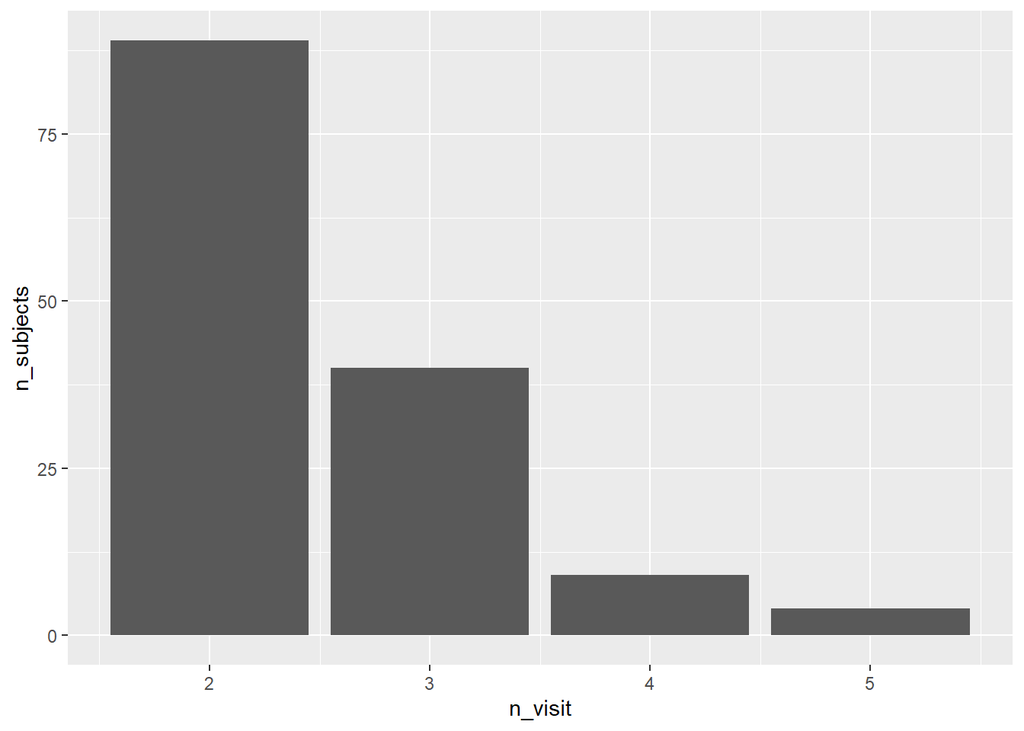

```r
visits %>%
  ggplot(aes(x = n_visit, n_subjects)) +
  geom_col()
```

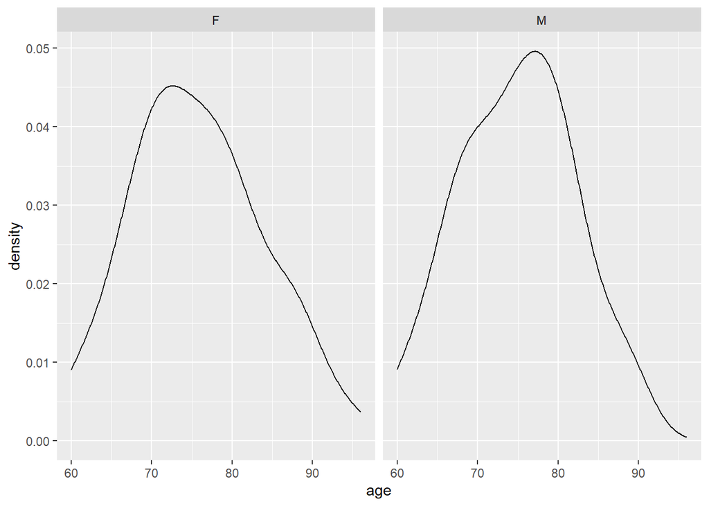

```r
subjects %>% filter(visit == 1) %>%
  ggplot(aes(x = age)) +
  geom_density() +
  facet_grid(. ~m_f)
```

```r
subjects %>% group_by(m_f) %>%
  summarise(mean_age = mean(age),
            n = length(age),
            mean_e_tiv = mean(e_tiv),
            mean_mmse = mean(mmse),
            mean_n_wbv = mean(n_wbv))
```

```
## # A tibble: 2 x 6
##   m_f   mean_age     n mean_e_tiv mean_mmse mean_n_wbv
##   <chr>    <dbl> <int>      <dbl>     <dbl>      <dbl>
## 1 F         77.2   204      1404.      27.9      0.738
## 2 M         76.8   150      1607.      26.7      0.719
```

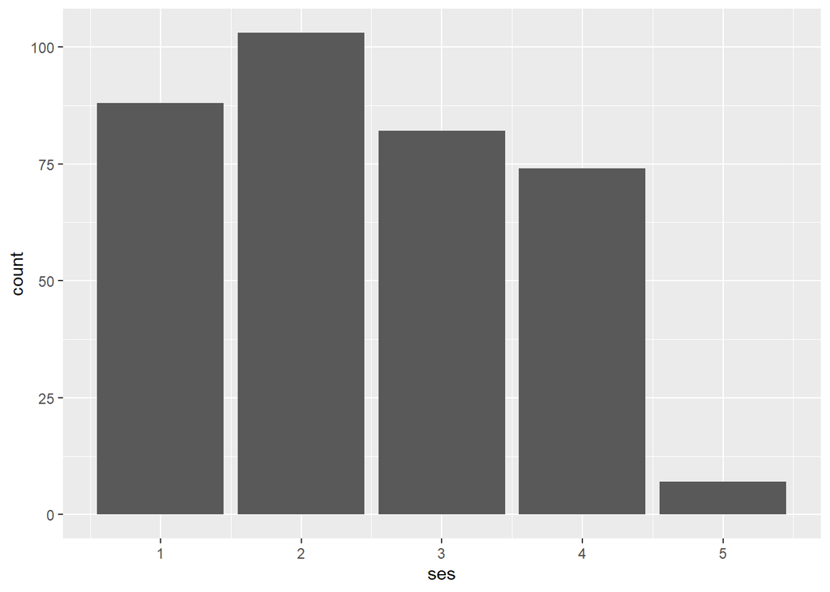

```r
subjects %>% ggplot(aes(x = ses)) + geom_bar()
```

The majority of subjects, 89 had two visits with 40 having three.

```r
knitr::kable(visits)
```

| n_visit | n_subjects |
| --- | --- |
| 2 | 89 |
| 3 | 40 |
| 4 | 9 |
| 5 | 4 |

Overview of distribution of variables and correlation between variables

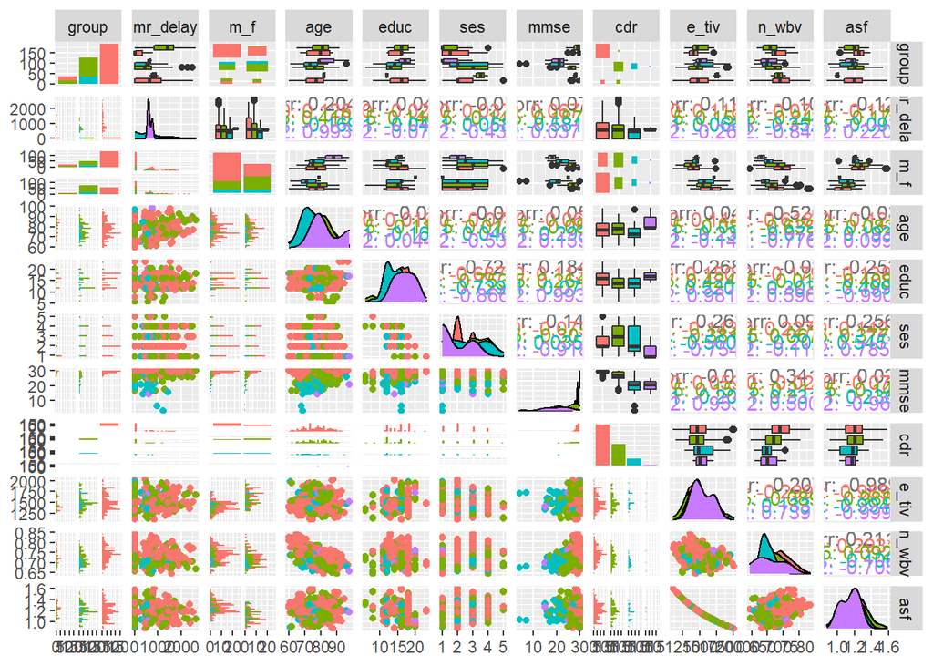

```r
subjects %>%
  select(-subject_id, -mri_id, -visit) %>%
  ggpairs(aes(color = cdr))
```

NOte: ASF and e_tiv are strongly colinear - therefore use just e_tiv

# PCA

Principal Components Analysis (PCA) is method to investigate whether you have groups or patterns in a dataset. It is a ‘data reduction’ or ‘dimension reduction’ method for continuous variables and creates a set of ‘components’ (axes) which are linear combinations of the original variables. PCA is useful when relatively few components are needed to capture most of the variation in the data.

Scaling: When the values in one variable are much bigger than in others we usually scale all the variable (mean of zero and a unit variance) before undertaking PCA to avoid the variable with the biggest values dominating the analysis. To see the variance accounted for by each component.

We only include the numeric variables: “age” “educ” “ses” “mmse” “e_tiv” “n_wbv”. cdr is excluded because it’s the response subject_id, mri_id, are excluded because they just id the observation visit is excluded because it is not informative group is excluded because it is not informative and collects potentially meaningful observations m_f is excluded because it is categorical so not suitable to PCA and LDA. It can be use in other methods.

Note, we only have 6 variables here: often PCA is carried out on many more variables

```r
pca <- subjects %>%
  select(age, educ, ses, mmse, e_tiv, n_wbv) %>%
  prcomp(scale. = TRUE)
```

```r
summary(pca)
```

```
## Importance of components:
##                           PC1    PC2    PC3    PC4     PC5    PC6
## Standard deviation     1.3957 1.2796 1.0189 0.8842 0.56769 0.5219
## Proportion of Variance 0.3247 0.2729 0.1730 0.1303 0.05371 0.0454
## Cumulative Proportion  0.3247 0.5976 0.7706 0.9009 0.95460 1.0000
```

```r
pca
```

```
## Standard deviations (1, .., p=6):
## [1] 1.3957251 1.2796002 1.0189025 0.8841592 0.5676858 0.5219271
##
## Rotation (n x k) = (6 x 6):
##              PC1        PC2          PC3         PC4          PC5         PC6
## age   -0.1397685  0.5397281 -0.606243009  0.01610692 -0.560496270  0.08492480
## educ  -0.6173294 -0.1905909  0.057526143 -0.26913628  0.008317592  0.71187551
## ses    0.6261403  0.1166607 -0.030463853  0.31591584  0.103518789  0.69490401
## mmse  -0.1543892 -0.4076621 -0.707873010  0.36685191  0.414258430 -0.05197113
## e_tiv -0.3890516  0.1413680  0.356555689  0.82716059 -0.130876711 -0.01409415
## n_wbv  0.1792215 -0.6874486 -0.003994105  0.09342612 -0.697366367  0.01515960
```

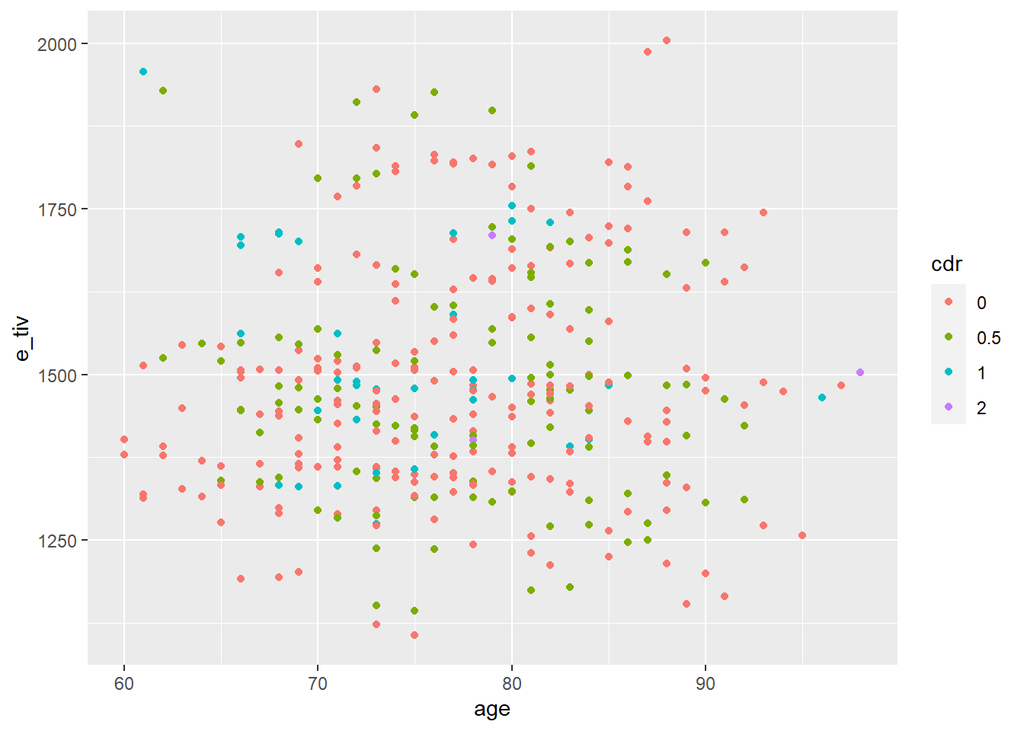

```r
subjects %>%
  ggplot(aes(x = age, y = e_tiv, colour = cdr)) +
  geom_point()
```

Three principal components capture 77% of the variation in the data. To plot, we might want to use the scores on each of the new axes and colour them by species. The scores are in a variable called $x

```r
# For convenience, I'll put these in one 'tidy' dataframe
# and add some labels
pca_labelled <- data.frame(pca$x,
                           cdr = subjects$cdr,
                           m_f = subjects$m_f)
```

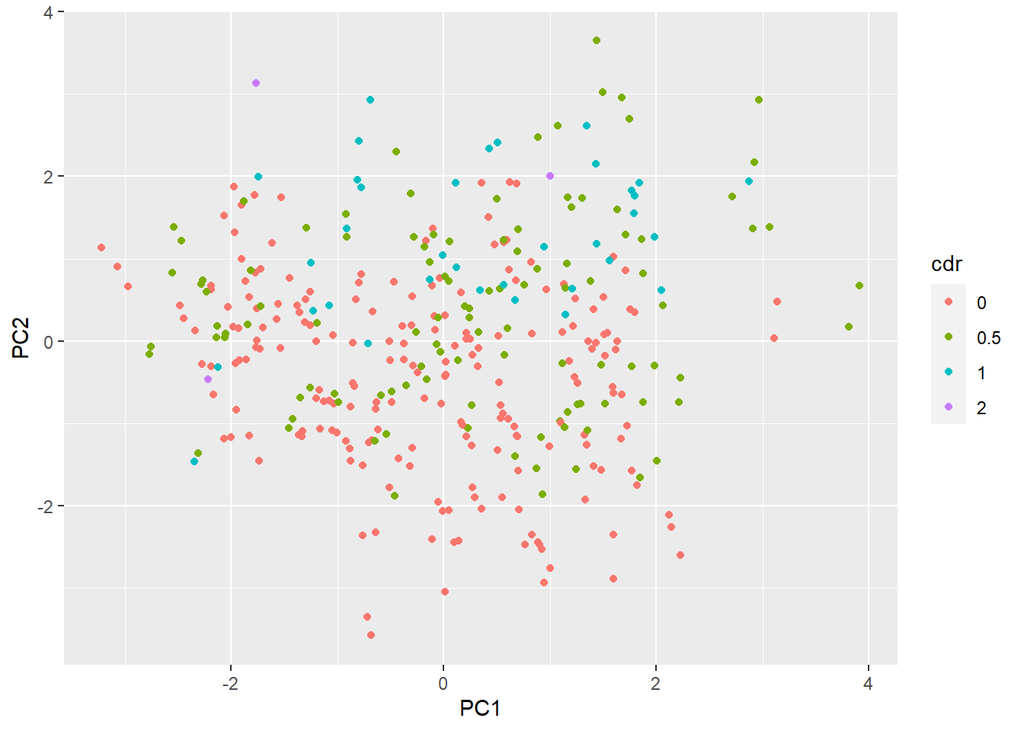

```r
# a then to do a scatterplot of the first two pc colour by cdr score
ggplot(pca_labelled,
       aes(x = PC1, y = PC2, color = cdr)) +
  geom_point()
```

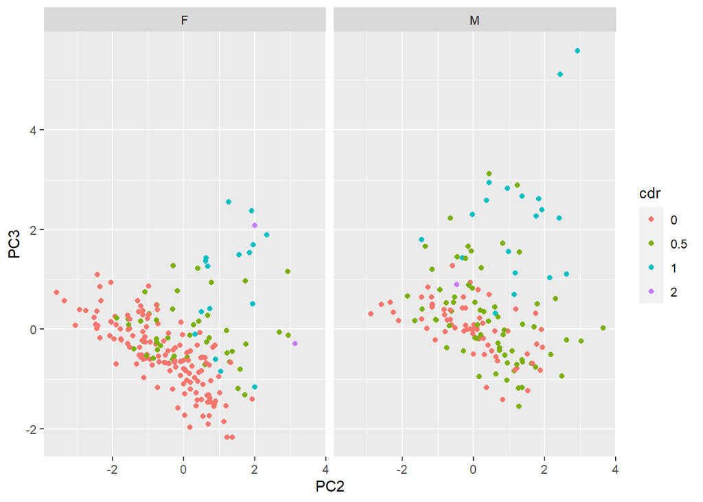

```r
# and by sex
ggplot(pca_labelled, aes(x = PC2, y = PC3, color = cdr)) +
  geom_point() +
  facet_grid(. ~ m_f)
```

# LDA

```r
lda <- subjects %>%
  select(age, educ, ses, mmse, e_tiv, n_wbv) %>%
  MASS::lda(grouping = subjects$cdr)
```

To determine how well the classes were predicted the scores on LD1 and LD2 and the classes need to be predicted:

```r
plda <- subjects %>%
  select(age, educ, ses, mmse, e_tiv, n_wbv) %>%
  predict(object = lda)
```

How many predicted classes are the same as the actual classes:

```r
mat <- confusionMatrix(plda$class, subjects$cdr)


mat
```

```
## Confusion Matrix and Statistics
##
##           Reference
## Prediction   0 0.5   1   2
##        0   201  62   3   1
##        0.5   5  36   8   0
##        1     0  11  24   1
##        2     0   1   0   1
##
## Overall Statistics
##
##                Accuracy : 0.7401
##                  95% CI : (0.6911, 0.785)
##     No Information Rate : 0.5819
##     P-Value [Acc > NIR] : 4.002e-10
##
##                   Kappa : 0.4884
##
##  Mcnemar's Test P-Value : 4.709e-10
##
## Statistics by Class:
##
##                      Class: 0 Class: 0.5 Class: 1 Class: 2
## Sensitivity            0.9757     0.3273  0.68571 0.333333
## Specificity            0.5541     0.9467  0.96238 0.997151
## Pos Pred Value         0.7528     0.7347  0.66667 0.500000
## Neg Pred Value         0.9425     0.7574  0.96541 0.994318
## Prevalence             0.5819     0.3107  0.09887 0.008475
## Detection Rate         0.5678     0.1017  0.06780 0.002825
## Detection Prevalence   0.7542     0.1384  0.10169 0.005650
## Balanced Accuracy      0.7649     0.6370  0.82405 0.665242
```

```r
# Confusion Matrix and Statistics
#
#           Reference
# Prediction   0 0.5   1   2
#        0   201  62   3   1
#        0.5   5  36   8   0
#        1     0  11  24   1
#        2     0   1   0   1

total <-  354
correct <- 201 + 36 + 24 + 1
commonest <- max(table(subjects$cdr))
# accuracy
acc <- correct/total

# 95% CI
binom.test(x = correct, n = total, p = 0.74)
```

```
##
##  Exact binomial test
##
## data:  correct and total
## number of successes = 262, number of trials = 354, p-value = 1
## alternative hypothesis: true probability of success is not equal to 0.74
## 95 percent confidence interval:
##  0.6911227 0.7850356
## sample estimates:
## probability of success
##               0.740113
```

```r
#no info rate
nir <- commonest / total

# P-Value [Acc > NIR]
binom.test(x = correct, n = total, p = nir, alternative = "greater")
```

```
##
##  Exact binomial test
##
## data:  correct and total
## number of successes = 262, number of trials = 354, p-value = 4.002e-10
## alternative hypothesis: true probability of success is greater than 0.5819209
## 95 percent confidence interval:
##  0.6989397 1.0000000
## sample estimates:
## probability of success
##               0.740113
```

```r
#sensitivity
# proportion true positive
201/206
```

```
## [1] 0.9757282
```

```r
#specificity
# proportion true negative
(36 + 8 + 0 + 11 + 24 + 1 + 1 + 0 + 1)/(total - 206)
```

```
## [1] 0.5540541
```

```r
# Pos Pred Value
# prob of being class given predicted that class
205/206
```

```
## [1] 0.9951456
```

The correct predictions are on the leading diagonal. So 201 of the 0 were correctly predicted but 5 were misclassified as 0.5. 62 of the 0.5 were misclassified as 0.

What are the most important errors?

## Training and Testing

A key part of using ML methods to make predictions is to test how good those predictions are. This is typically done by training the model on about 75% of your data and then testing it on the remainder.

The caret package includes functions to help with this (as well as lots of ML algorithms). The name comes from Classification And REgression Training

Split the dataset in to training and testing sets using createDataPartition()

```r
ids <- createDataPartition(y = subjects$cdr, p = 0.75, list = FALSE)
str(ids)
```

```
##  int [1:268, 1] 1 2 3 4 5 6 7 10 11 15 ...
##  - attr(*, "dimnames")=List of 2
##   ..$ : NULL
##   ..$ : chr "Resample1"
```

Now use those row numbers to create the training and test datasets.

```r
train <- subjects %>% slice(ids)
test <- subjects %>% slice(-ids)
```

Perform the lda on the training data and test on the test data

```r
# train
lda <- train %>%
  select(age, educ, ses, mmse, e_tiv, n_wbv) %>%
  MASS::lda(grouping = train$cdr)
```

```r
plda <- test %>%
  select(age, educ, ses, mmse, e_tiv, n_wbv) %>%
  predict(object = lda)
```

Evaluate the model performance by comparing the predicted classes to the actual classes.

```r
confusionMatrix(plda$class, test$cdr)
```

```
## Confusion Matrix and Statistics
##
##           Reference
## Prediction  0 0.5  1  2
##        0   48  14  0  0
##        0.5  3  11  1  0
##        1    0   1  6  0
##        2    0   1  1  0
##
## Overall Statistics
##
##                Accuracy : 0.7558
##                  95% CI : (0.6513, 0.842)
##     No Information Rate : 0.593
##     P-Value [Acc > NIR] : 0.001159
##
##                   Kappa : 0.5213
##
##  Mcnemar's Test P-Value : NA
##
## Statistics by Class:
##
##                      Class: 0 Class: 0.5 Class: 1 Class: 2
## Sensitivity            0.9412     0.4074  0.75000       NA
## Specificity            0.6000     0.9322  0.98718  0.97674
## Pos Pred Value         0.7742     0.7333  0.85714       NA
## Neg Pred Value         0.8750     0.7746  0.97468       NA
## Prevalence             0.5930     0.3140  0.09302  0.00000
## Detection Rate         0.5581     0.1279  0.06977  0.00000
## Detection Prevalence   0.7209     0.1744  0.08140  0.02326
## Balanced Accuracy      0.7706     0.6698  0.86859       NA
```

It’s the observed 0.5 which are hardest to predict. We can also see that in the PCA.

# Random Forest

Another supervised learning method. It generates a re large number of decision trees each constructed from a different subset of the training data. The decision trees are then used to create a classification consensus.

It can cope with both continuous and categorical predictors. We again partition our dataset in to training and testing components.

```r
ids <- createDataPartition(subjects$cdr,
                             p = .75,
                             list = F)
training <- subjects %>%
  slice(ids) %>%
  select(age,
         educ,
         ses,
         mmse,
         e_tiv,
         n_wbv,
         m_f,
         cdr)
testing <- subjects %>%
  slice(-ids) %>%
  select(age,
         educ,
         ses,
         mmse,
         e_tiv,
         n_wbv,
         m_f,
         cdr)
```

Train the model

```r
library(randomForest)
rf_classifier <- randomForest(cdr ~ .,
                             data = training,
                             ntree = 200,
                             mtry = 3,
                             importance = TRUE)

rf_classifier
```

```
##
## Call:
##  randomForest(formula = cdr ~ ., data = training, ntree = 200,      mtry = 3, importance = TRUE)
##                Type of random forest: classification
##                      Number of trees: 200
## No. of variables tried at each split: 3
##
##         OOB estimate of  error rate: 26.49%
## Confusion matrix:
##       0 0.5  1 2 class.error
## 0   139  16  0 0   0.1032258
## 0.5  31  44  8 0   0.4698795
## 1     2  11 14 0   0.4814815
## 2     0   1  2 0   1.0000000
```

OOB (Out-of-bag) estimate of error rate: number of incorrectly classified / number observations (i.e, counterpart to accuracy)

Important of each variable:

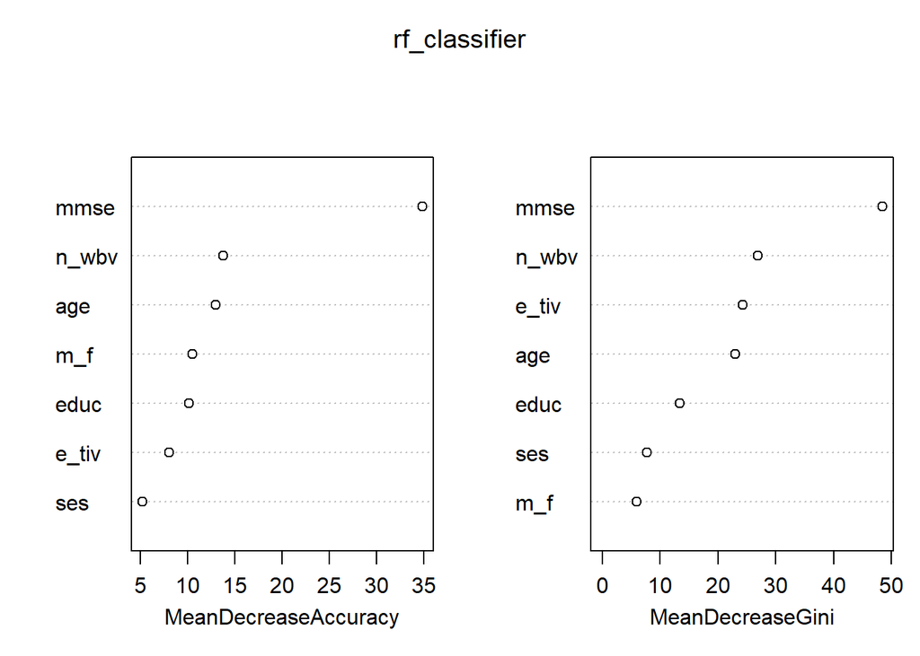

```r
varImpPlot(rf_classifier)
```

MeanDecreaseAccuracy - loss of prediction performance when a that variable is excluded. MeanDecreaseGin - GINI is a measure of node impurity. It indicates how good that variable is for classifying the data.

Confusion matrix.

```r
prediction_for_table <- predict(rf_classifier,testing[,-8])
confusionMatrix(prediction_for_table, test$cdr)
```

```
## Confusion Matrix and Statistics
##
##           Reference
## Prediction  0 0.5  1  2
##        0   32  17  8  0
##        0.5 15   7  0  0
##        1    4   3  0  0
##        2    0   0  0  0
##
## Overall Statistics
##
##                Accuracy : 0.4535
##                  95% CI : (0.3458, 0.5645)
##     No Information Rate : 0.593
##     P-Value [Acc > NIR] : 0.9967
##
##                   Kappa : -0.0529
##
##  Mcnemar's Test P-Value : NA
##
## Statistics by Class:
##
##                      Class: 0 Class: 0.5 Class: 1 Class: 2
## Sensitivity            0.6275     0.2593  0.00000       NA
## Specificity            0.2857     0.7458  0.91026        1
## Pos Pred Value         0.5614     0.3182  0.00000       NA
## Neg Pred Value         0.3448     0.6875  0.89873       NA
## Prevalence             0.5930     0.3140  0.09302        0
## Detection Rate         0.3721     0.0814  0.00000        0
## Detection Prevalence   0.6628     0.2558  0.08140        0
## Balanced Accuracy      0.4566     0.5025  0.45513       NA
```

randomForestExplainer

```r
# library(randomForestExplainer)
# explain_forest(rf_classifier, interactions = TRUE, data = training)
```